# Elevation Crosswalk: USBR Hydromet/USGS Elevations & WET Surface Water Extent

Maddee Wiggins

2026-08-06

```r
library(tidyverse)
library(sf)
library(ggplot2)
library(scales)
library(patchwork)
library(knitr)
library(leaflet)
```

# Overview

This document crosswalks water-surface-**elevation** stations from `teacup_diagram_data` (https://www.usbr.gov/pn/hydromet/klamath/teacup.html) to Klamath Basin wildlife refuges (`rivermile::klamath_refuges`) and lakes/reservoirs (`rivermile::klamath_lakes`), then joins each matched station’s monthly water level to the processed WET (Intermountain West Joint Venture (IWJV)) monthly surface water extent data (`wet_surface_water`) for that area. The goal is a combined monthly view — station water level alongside wetland/lake surface water extent — for areas with a relevant elevation gauge.

The area/station crosswalk is a hand-curated lookup (Section 4); only stations that are actually on or clearly hydrologically tied to an area are assigned to it. `wet_surface_water`/ `wet_hydroperiod` key on a `name` column with a `boundary_type` of `"refuge"` or `"lake"` — see `data-raw/processing-scripts/wet-process-data.R` for how those ids are built. **Bear Valley, Klamath Marsh, Lower Klamath/Sheepy refuges, and Lower Klamath Lake** have no station assigned and are excluded from the combined analysis.

# 1. Data processing notes

1. **Surface water extent** (`wet_surface_water`/`wet_hydroperiod`) is calculated within a **0.5-mile buffer** around each refuge/lake polygon (`rivermile::klamath_refuges` / `rivermile::klamath_lakes`), not the raw polygon boundary itself — see `data-raw/processing-scripts/wet-process-data.R`.
2. **Elevation** is currently crosswalked from `teacup_diagram_data` as the default source (Section 4). This is a hand-curated, on-site-only crosswalk, not exhaustive — additional candidate gages at **Upper Klamath Lake** are compared in Section 4.2.
3. See Section 4.1 for a map showing all stations against the refuge/lake boundaries.

# 2. Load data

```r
data("wet_surface_water",    package = "klamathWaterData")
data("teacup_diagram_data",  package = "klamathWaterData")

refuges <- rivermile::klamath_refuges
lakes <- rivermile::klamath_lakes

cat("wet_surface_water:  ", nrow(wet_surface_water),   "rows\n")
```

```
## wet_surface_water:   836 rows
```

```r
cat("teacup_diagram_data:", nrow(teacup_diagram_data), "rows\n")
```

```
## teacup_diagram_data: 197072 rows
```

```r
cat("refuges:            ", nrow(refuges),             "features\n")
```

```
## refuges:             6 features
```

```r
cat("lakes:              ", nrow(lakes),               "features\n")
```

```
## lakes:               5 features
```

```r
kable(st_drop_geometry(refuges), caption = "rivermile::klamath_refuges")
```

rivermile::klamath_refuges

| orgname |
| --- |
| bear valley national wildlife refuge |
| clear lake national wildlife refuge |
| klamath marsh national wildlife refuge |
| lower klamath national wildlife refuge |
| tule lake national wildlife refuge |
| upper klamath national wildlife refuge |

```r
kable(st_drop_geometry(lakes),   caption = "rivermile::klamath_lakes")
```

rivermile::klamath_lakes

| lake_name | area_sq_km |
| --- | --- |
| clear lake reservoir | 65.52828 |
| gerber reservoir | 15.42681 |
| lower klamath lake | 5.51700 |
| tule lake | 29.33804 |
| upper klamath lake | 251.28954 |

# 3. Elevation stations in `teacup_diagram_data`

`teacup_diagram_data$measure_type` is one of `elevation`, `storage`, or `flow`. We keep only `elevation` — reservoir/lake water-surface elevation and gauge height, which is what can plausibly track an area’s wetland/lake extent. `lat`/`long` are already included in this dataset (sourced from the USBR RISE API for USBR Hydromet sites, and `dataRetrieval::readNWISsite()` for USGS sites — see `data-raw/data-pull/teacup-diagram-data-pull.R`).

```r
elev_stations <- teacup_diagram_data |>
  filter(measure_type == "elevation") |>
  distinct(source, site, label, lat, long)

stations_sf <- elev_stations |>
  st_as_sf(coords = c("long", "lat"), crs = 4326, remove = FALSE)

kable(elev_stations, caption = "Elevation stations available in teacup_diagram_data")
```

Elevation stations available in teacup_diagram_data

| source | site | label | lat | long |
| --- | --- | --- | --- | --- |
| USBR Hydromet | GER | Gerber Reservoir - Forebay Elevation (ft) | 42.20127 | -121.1298 |
| USBR Hydromet | CLK | Clear Lake West Lobe - Forebay Elevation (ft) | 41.84663 | -121.2096 |
| USBR Hydromet | MAL | Malone Reservoir - Gage Height (ft) | 42.00577 | -121.2240 |
| USBR Hydromet | TULC | Tule Lake Sump 1A - Forebay Elevation (ft) | 41.87862 | -121.5453 |
| USBR Hydromet | TULC2 | Tule Lake Sump 1B - Forebay Elevation (ft) | 41.85328 | -121.4925 |
| USGS NWIS | 11507001 | Upper Klamath Lake nr Klamath Falls - Elevation (ft) | 42.24983 | -121.8164 |

# 4. Spatial crosswalk of elevation sites with refuges and lakes

`wet_surface_water`/`wet_hydroperiod` identify each area with a `name` id built in `data-raw/processing-scripts/wet-process-data.R`: refuge ids are suffixed `_refuge` (e.g. `clear_lake_refuge`), lake ids are not (e.g. `clear_lake_reservoir`) — the two id lookups below mirror that script exactly so the crosswalk here lines up with the actual dataset.

```r
refuge_id_lookup <- tribble(
  ~name,                         ~orgname,
  "upper_klamath_lake_refuge",   "upper klamath national wildlife refuge",
  "clear_lake_refuge",           "clear lake national wildlife refuge",
  "tule_lake_refuge",            "tule lake national wildlife refuge",
  "bear_valley_refuge",          "bear valley national wildlife refuge",
  "lower_klamath_sheepy_refuge", "lower klamath national wildlife refuge",
  "klamath_marsh_refuge",        "klamath marsh national wildlife refuge"
)

lake_id_lookup <- tribble(
  ~name,                   ~lake_name,
  "clear_lake_reservoir",  "clear lake reservoir",
  "gerber_reservoir",      "gerber reservoir",
  "lower_klamath_lake",    "lower klamath lake",
  "tule_lake",             "tule lake",
  "upper_klamath_lake",    "upper klamath lake"
)

refuges_named <- refuges |> inner_join(refuge_id_lookup, by = "orgname")
lakes_named   <- lakes   |> inner_join(lake_id_lookup,   by = "lake_name")
```

Each elevation station is assigned to an area only where it is genuinely on-site or the obvious controlling structure — not just the nearest point on a map:

- **Tule Lake NWR** and **Tule Lake** (the lake itself) — `TULC` and `TULC2`, the Sump 1A and Sump 1B forebay gauges inside the refuge boundary.
- **Clear Lake NWR** and **Clear Lake Reservoir** — `CLK`, Clear Lake West Lobe, inside both boundaries.
- **Upper Klamath Lake NWR** and **Upper Klamath Lake** — `11507001`, the USGS lake-elevation gauge near Link River Dam.
- **Gerber Reservoir** — `GER`, the reservoir’s own forebay elevation gauge (there is no matching refuge boundary for Gerber, only the lake).
- **Bear Valley, Klamath Marsh, Lower Klamath/Sheepy refuges, and Lower Klamath Lake** — no station assigned.

```r
crosswalk <- tribble(
  ~name,                       ~site,
  "tule_lake_refuge",          "TULC",
  "tule_lake_refuge",          "TULC2",
  "tule_lake",                 "TULC",
  "tule_lake",                 "TULC2",
  "upper_klamath_lake_refuge", "11507001",
  "upper_klamath_lake",        "11507001",
  "clear_lake_refuge",         "CLK",
  "clear_lake_reservoir",      "CLK",
  "gerber_reservoir",          "GER"
)

stations_area_cross <- stations_sf |>
  left_join(crosswalk, by = "site")

stations_area_cross |>
  st_drop_geometry() |>
  kable(caption = "Area x station crosswalk (NA = elevation station not assigned to an area)")
```

Area x station crosswalk (NA = elevation station not assigned to an area)

| source | site | label | lat | long | name |
| --- | --- | --- | --- | --- | --- |
| USBR Hydromet | GER | Gerber Reservoir - Forebay Elevation (ft) | 42.20127 | -121.1298 | gerber_reservoir |
| USBR Hydromet | CLK | Clear Lake West Lobe - Forebay Elevation (ft) | 41.84663 | -121.2096 | clear_lake_refuge |
| USBR Hydromet | CLK | Clear Lake West Lobe - Forebay Elevation (ft) | 41.84663 | -121.2096 | clear_lake_reservoir |
| USBR Hydromet | MAL | Malone Reservoir - Gage Height (ft) | 42.00577 | -121.2240 | NA |
| USBR Hydromet | TULC | Tule Lake Sump 1A - Forebay Elevation (ft) | 41.87862 | -121.5453 | tule_lake_refuge |
| USBR Hydromet | TULC | Tule Lake Sump 1A - Forebay Elevation (ft) | 41.87862 | -121.5453 | tule_lake |
| USBR Hydromet | TULC2 | Tule Lake Sump 1B - Forebay Elevation (ft) | 41.85328 | -121.4925 | tule_lake_refuge |
| USBR Hydromet | TULC2 | Tule Lake Sump 1B - Forebay Elevation (ft) | 41.85328 | -121.4925 | tule_lake |
| USGS NWIS | 11507001 | Upper Klamath Lake nr Klamath Falls - Elevation (ft) | 42.24983 | -121.8164 | upper_klamath_lake_refuge |
| USGS NWIS | 11507001 | Upper Klamath Lake nr Klamath Falls - Elevation (ft) | 42.24983 | -121.8164 | upper_klamath_lake |

## 4.1 Maps: refuges & lakes with elevation stations

```r
# ---- teacup_diagram_data -> sf points, one row per station ----
# teacup_diagram_data is a long daily time series (197k rows); collapse to
# one point per station (some sites have multiple measure_types, e.g. GER
# has both elevation and storage — combine those into one popup).
teacup_diagram_sf <- klamathWaterData::teacup_diagram_data |>
  filter(measure_type == "elevation") |>
  group_by(source, site, lat, long) |>
  summarise(
    measures = paste(sort(unique(measure_type)), collapse = ", "),
    labels   = paste(unique(label), collapse = "<br>"),
    .groups  = "drop"
  ) |>
  st_as_sf(coords = c("long", "lat"), crs = 4326, remove = FALSE)

# ---- water_level_gage markers (from earlier session work) ----
gages <- klamathWaterData::water_level_gage |>
  mutate(
    latitude  = if_else(gage_id == "usbr tule lake sump 1a", 41.878620, latitude),
    longitude = if_else(gage_id == "usbr tule lake sump 1a", -121.545291, longitude),
    marker_color = case_when(
      agency == "USGS"                       ~ "steelblue",
      agency == "u.s. bureau of reclamation" ~ "darkorange"
    )
  )

# ---- refuges / lakes (lakes cleaned: Tule Lake's distant outlier part dropped — see wet-process-data.R) ----
refuges <- rivermile::klamath_refuges

# ---- map ----
leaflet() |>
  addProviderTiles(providers$CartoDB.Positron) |>
  setView(lng = -121.8, lat = 42.1, zoom = 8) |>
  addPolygons(
    data = refuges,
    color = "darkgreen", weight = 1.5, fillOpacity = 0.15,
    label = ~orgname,
    group = "Refuges"
  ) |>
  addPolygons(
    data = lakes,
    color = "darkblue", weight = 1.5, fillOpacity = 0.15,
    label = ~lake_name,
    group = "Lakes"
  ) |>
  addCircleMarkers(
    data = gages,
    lng = ~longitude, lat = ~latitude,
    radius = 7,
    color = ~marker_color,
    stroke = FALSE,
    fillOpacity = 0.85,
    label = ~gage_name,
    popup = ~paste0(
      "<b>", gage_name, "</b><br>",
      "Gage ID: ", gage_id, "<br>",
      "Agency: ", agency, "<br>",
      "Location: ", location
    ),
    group = "Water Level Gages"
  ) |>
  addCircleMarkers(
    data = teacup_diagram_sf,
    radius = 6,
    color = "purple",
    stroke = TRUE, weight = 1, opacity = 1,
    fillOpacity = 0.6,
    label = ~site,
    popup = ~paste0(
      "<b>", site, "</b><br>",
      "Source: ", source, "<br>",
      "Measures: ", measures, "<br>",
      labels
    ),
    group = "Teacup Diagram Stations"
  ) |>
  addLegend(
    position = "bottomright",
    colors = c("steelblue", "darkorange", "purple"),
    labels = c("USGS gage", "USBR gage", "Teacup diagram station"),
    title = "Legend"
  ) |>
  addLayersControl(
    overlayGroups = c("Refuges", "Lakes", "Water Level Gages", "Teacup Diagram Stations"),
    options = layersControlOptions(collapsed = FALSE)
  )
```

[interactive chart not shown]

## 4.2 Comparing Upper Klamath Lake elevation gages

`water_level_gage` lists four USGS gages around Upper Klamath Lake, but only one of them (`11507001`, near Link River Dam) is used in the crosswalk above. Comparing all four’s temporal coverage and values here to check whether `11507001` is still the best choice, or whether swapping to or supplementing it with another gage is worth exploring (see the note in Section 1).

```r
klamath_gages <- c("11505800", "11504300", "11505900", "11507001")

klamath_elev_gages <- klamathWaterData::water_level_data |>
  filter(gage_id %in% klamath_gages)

klamath_elev_gages |>
  group_by(gage_name, gage_id) |>
  summarise(
    start    = min(date),
    end      = max(date),
    n_obs    = n(),
    min_ft   = round(min(value, na.rm = TRUE), 1),
    max_ft   = round(max(value, na.rm = TRUE), 1),
    .groups  = "drop"
  ) |>
  arrange(gage_id) |>
  kable(caption = "Upper Klamath Lake candidate elevation gages — coverage and range")
```

Upper Klamath Lake candidate elevation gages — coverage and range

| gage_name | gage_id | start | end | n_obs | min_ft | max_ft |
| --- | --- | --- | --- | --- | --- | --- |
| agency lake near klamath agency, or | 11504300 | 2014-01-01 | 2025-08-21 | 4242 | 4137.8 | 4143.3 |
| upper klamath lake at rocky point, or | 11505800 | 2014-01-01 | 2025-08-21 | 4202 | 4138.0 | 4143.3 |
| upper klamath lake at rattlesnake point, or | 11505900 | 2014-01-01 | 2025-08-21 | 4159 | 4137.9 | 4143.3 |
| upper klamath lake nr k.falls(weight/mean elev) or | 11507001 | 2014-01-01 | 2025-08-21 | 4251 | 4138.0 | 4143.3 |

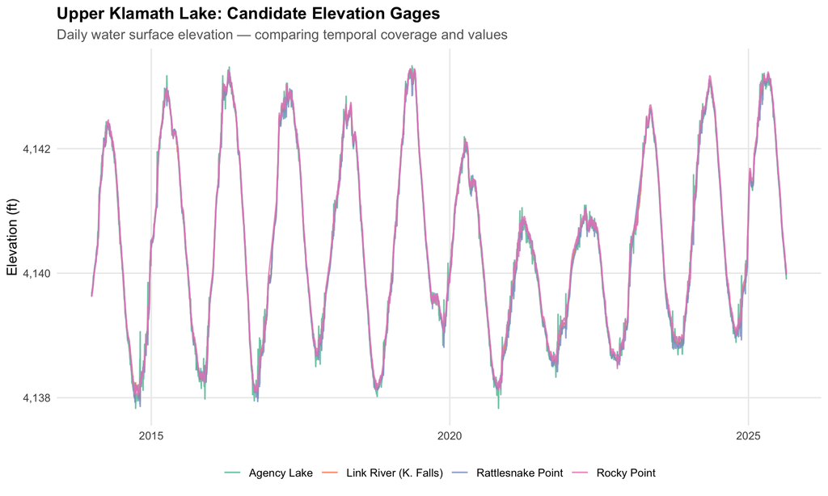

```r
gage_short_labels <- c(
  "11504300" = "Agency Lake",
  "11505900" = "Rattlesnake Point",
  "11505800" = "Rocky Point",
  "11507001" = "Link River (K. Falls)"
)

klamath_elev_gages |>
  mutate(gage_label = gage_short_labels[gage_id]) |>
  ggplot(aes(x = date, y = value, color = gage_label)) +
  geom_line(linewidth = 0.6, alpha = 0.85) +
  scale_color_brewer(palette = "Set2", name = NULL) +
  scale_y_continuous(labels = label_comma()) +
  labs(
    title    = "Upper Klamath Lake: Candidate Elevation Gages",
    subtitle = "Daily water surface elevation — comparing temporal coverage and values",
    x        = NULL,
    y        = "Elevation (ft)"
  ) +
  theme_minimal(base_size = 12) +
  theme(
    legend.position  = "bottom",
    plot.title       = element_text(face = "bold"),
    plot.subtitle    = element_text(color = "grey40"),
    panel.grid.minor = element_blank()
  )
```

# 5. Monthly water level & WET surface water extent

`wet_surface_water` has two temporal structures: decadal composites (`is_decadal == TRUE`, one value per calendar month averaged over a 10-year era) and individual calendar months from 2022 onward (`is_decadal == FALSE`, `era_start` is the actual year). We match each structure to the elevation record at the same resolution: a decadal climatological monthly mean for decadal rows, and the actual year-month mean for annual rows. Where an area has multiple stations (Tule Lake’s two sumps), their monthly values are averaged together first. Alongside the mean we also keep the min/max elevation observed within each aggregation window, used for the range ribbon in Section 6.1. Joining directly on `name` — the same id `wet_surface_water` uses — means both refuges and lakes fall out of one join, with no separate refuge/lake handling needed.

```r
elev_xwalk_data <- teacup_diagram_data |>
  filter(measure_type == "elevation") |>
  # many-to-many is expected: TULC/TULC2 map to both tule_lake_refuge and tule_lake,
  # 11507001 maps to both upper_klamath_lake_refuge and upper_klamath_lake, CLK maps to
  # both clear_lake_refuge and clear_lake_reservoir
  inner_join(crosswalk, by = "site", relationship = "many-to-many")

elev_monthly_decadal <- elev_xwalk_data |>
  mutate(year = year(date), month_num = month(date)) |>
  mutate(era_str = case_when(
    year >= 2005 & year <= 2014 ~ "2005-2014",
    year >= 2015 & year <= 2022 ~ "2015-2022",
    TRUE ~ NA_character_
  )) |>
  filter(!is.na(era_str)) |>
  group_by(name, era_str, month_num) |>
  summarise(elevation_mean_ft = mean(value, na.rm = TRUE),
            elevation_min_ft  = min(value, na.rm = TRUE),
            elevation_max_ft  = max(value, na.rm = TRUE), .groups = "drop") |>
  mutate(is_decadal = TRUE)

elev_monthly_annual <- elev_xwalk_data |>
  mutate(year = year(date), month_num = month(date)) |>
  filter(year >= 2022) |>
  group_by(name, era_start = year, month_num) |>
  summarise(elevation_mean_ft = mean(value, na.rm = TRUE),
            elevation_min_ft  = min(value, na.rm = TRUE),
            elevation_max_ft  = max(value, na.rm = TRUE), .groups = "drop") |>
  mutate(is_decadal = FALSE)

combined_decadal <- wet_surface_water |>
  filter(is_decadal) |>
  inner_join(elev_monthly_decadal, by = c("name", "is_decadal", "era_str", "month_num"))

combined_annual <- wet_surface_water |>
  filter(!is_decadal) |>
  inner_join(elev_monthly_annual, by = c("name", "is_decadal", "era_start", "month_num"))

combined_monthly <- bind_rows(combined_decadal, combined_annual) |>
  arrange(name, is_decadal, era_start, month_num)

plot_areas <- sort(unique(combined_monthly$name))

cat("Combined monthly rows (decadal):", nrow(combined_decadal), "\n")
```

```
## Combined monthly rows (decadal): 140
```

```r
cat("Combined monthly rows (annual): ", nrow(combined_annual), "\n")
```

```
## Combined monthly rows (annual):  348
```

```r
cat("Areas represented:", paste(plot_areas, collapse = ", "), "\n")
```

```
## Areas represented: clear_lake_refuge, clear_lake_reservoir, gerber_reservoir, tule_lake, tule_lake_refuge, upper_klamath_lake, upper_klamath_lake_refuge
```

```r
kable(head(combined_monthly, 10), caption = "combined_monthly — first rows")
```

combined_monthly — first rows

| name | boundary_type | type | era_str | is_decadal | era_start | month_chr | month_num | mean_val | median_val | sd_val | n_pixels | elevation_mean_ft | elevation_min_ft | elevation_max_ft |
| --- | --- | --- | --- | --- | --- | --- | --- | --- | --- | --- | --- | --- | --- | --- |
| clear_lake_refuge | refuge | SurfaceWater | 2022 | FALSE | 2022 | JAN | 1 | 0.5010651 | 0.4805832 | 0.2118977 | 79517 | 4521.973 | 4521.69 | 4522.11 |
| clear_lake_refuge | refuge | SurfaceWater | 2022 | FALSE | 2022 | FEB | 2 | 0.6734773 | 0.6807486 | 0.0719613 | 93739 | 4522.089 | 4522.03 | 4522.13 |
| clear_lake_refuge | refuge | SurfaceWater | 2022 | FALSE | 2022 | MAR | 3 | 0.6179621 | 0.6430097 | 0.0981916 | 66682 | 4522.068 | 4521.96 | 4522.16 |
| clear_lake_refuge | refuge | SurfaceWater | 2022 | FALSE | 2022 | APR | 4 | 0.6534664 | 0.6658430 | 0.0683885 | 95102 | 4522.124 | 4521.87 | 4522.44 |
| clear_lake_refuge | refuge | SurfaceWater | 2022 | FALSE | 2022 | MAY | 5 | 0.5699749 | 0.5788411 | 0.0692757 | 93910 | 4522.266 | 4522.04 | 4522.44 |
| clear_lake_refuge | refuge | SurfaceWater | 2022 | FALSE | 2022 | JUN | 6 | 0.4801223 | 0.4931658 | 0.1110754 | 89747 | 4521.870 | 4521.58 | 4522.08 |
| clear_lake_refuge | refuge | SurfaceWater | 2022 | FALSE | 2022 | JUL | 7 | 0.6397796 | 0.6486103 | 0.0643540 | 85146 | 4521.230 | 4520.90 | 4521.54 |
| clear_lake_refuge | refuge | SurfaceWater | 2022 | FALSE | 2022 | AUG | 8 | 0.4919869 | 0.4901429 | 0.0539774 | 76223 | 4520.580 | 4520.27 | 4520.88 |
| clear_lake_refuge | refuge | SurfaceWater | 2022 | FALSE | 2022 | SEP | 9 | 0.5397232 | 0.5321298 | 0.0553418 | 58605 | 4520.097 | 4519.89 | 4520.29 |
| clear_lake_refuge | refuge | SurfaceWater | 2022 | FALSE | 2022 | OCT | 10 | 0.6058281 | 0.6114628 | 0.0490509 | 56665 | 4519.863 | 4519.77 | 4519.95 |

## 5.1 Package dataset: `refuge_elevation_wetland`

`combined_decadal` and `combined_annual` are working objects scoped to this document. For downstream use in the package, they’re combined (via `combined_monthly`) into a single, tidy, renamed dataset — one row per area-month, elevation and WET columns clearly distinguished by prefix, `boundary_type` carried through from `wet_surface_water` — and saved as `refuge_elevation_wetland`.

```r
refuge_elevation_wetland <- combined_monthly |>
  transmute(
    name,
    boundary_type,
    is_decadal,
    era_str,
    era_start,
    month_num,
    month_chr,
    elevation_mean_ft,
    elevation_min_ft,
    elevation_max_ft,
    wet_mean_val   = mean_val,
    wet_median_val = median_val,
    wet_sd_val     = sd_val,
    wet_n_pixels   = n_pixels
  ) |>
  arrange(name, is_decadal, era_start, month_num) |>
  mutate(month_chr = tolower(month_chr)) |>
  select(-era_start)

glimpse(refuge_elevation_wetland)
```

```
## Rows: 488
## Columns: 13
## $ name              <chr> "clear_lake_refuge", "clear_lake_refuge", "clear_lak…
## $ boundary_type     <chr> "refuge", "refuge", "refuge", "refuge", "refuge", "r…
## $ is_decadal        <lgl> FALSE, FALSE, FALSE, FALSE, FALSE, FALSE, FALSE, FAL…
## $ era_str           <chr> "2022", "2022", "2022", "2022", "2022", "2022", "202…
## $ month_num         <dbl> 1, 2, 3, 4, 5, 6, 7, 8, 9, 10, 11, 12, 1, 2, 3, 4, 5…
## $ month_chr         <chr> "jan", "feb", "mar", "apr", "may", "jun", "jul", "au…
## $ elevation_mean_ft <dbl> 4521.973, 4522.089, 4522.068, 4522.124, 4522.266, 45…
## $ elevation_min_ft  <dbl> 4521.69, 4522.03, 4521.96, 4521.87, 4522.04, 4521.58…
## $ elevation_max_ft  <dbl> 4522.11, 4522.13, 4522.16, 4522.44, 4522.44, 4522.08…
## $ wet_mean_val      <dbl> 0.5010651, 0.6734773, 0.6179621, 0.6534664, 0.569974…
## $ wet_median_val    <dbl> 0.4805832, 0.6807486, 0.6430097, 0.6658430, 0.578841…
## $ wet_sd_val        <dbl> 0.21189772, 0.07196126, 0.09819164, 0.06838854, 0.06…
## $ wet_n_pixels      <int> 79517, 93739, 66682, 95102, 93910, 89747, 85146, 762…
```

```r
kable(head(refuge_elevation_wetland, 10), caption = "refuge_elevation_wetland — first rows")
```

refuge_elevation_wetland — first rows

| name | boundary_type | is_decadal | era_str | month_num | month_chr | elevation_mean_ft | elevation_min_ft | elevation_max_ft | wet_mean_val | wet_median_val | wet_sd_val | wet_n_pixels |
| --- | --- | --- | --- | --- | --- | --- | --- | --- | --- | --- | --- | --- |
| clear_lake_refuge | refuge | FALSE | 2022 | 1 | jan | 4521.973 | 4521.69 | 4522.11 | 0.5010651 | 0.4805832 | 0.2118977 | 79517 |
| clear_lake_refuge | refuge | FALSE | 2022 | 2 | feb | 4522.089 | 4522.03 | 4522.13 | 0.6734773 | 0.6807486 | 0.0719613 | 93739 |
| clear_lake_refuge | refuge | FALSE | 2022 | 3 | mar | 4522.068 | 4521.96 | 4522.16 | 0.6179621 | 0.6430097 | 0.0981916 | 66682 |
| clear_lake_refuge | refuge | FALSE | 2022 | 4 | apr | 4522.124 | 4521.87 | 4522.44 | 0.6534664 | 0.6658430 | 0.0683885 | 95102 |
| clear_lake_refuge | refuge | FALSE | 2022 | 5 | may | 4522.266 | 4522.04 | 4522.44 | 0.5699749 | 0.5788411 | 0.0692757 | 93910 |
| clear_lake_refuge | refuge | FALSE | 2022 | 6 | jun | 4521.870 | 4521.58 | 4522.08 | 0.4801223 | 0.4931658 | 0.1110754 | 89747 |
| clear_lake_refuge | refuge | FALSE | 2022 | 7 | jul | 4521.230 | 4520.90 | 4521.54 | 0.6397796 | 0.6486103 | 0.0643540 | 85146 |
| clear_lake_refuge | refuge | FALSE | 2022 | 8 | aug | 4520.580 | 4520.27 | 4520.88 | 0.4919869 | 0.4901429 | 0.0539774 | 76223 |
| clear_lake_refuge | refuge | FALSE | 2022 | 9 | sep | 4520.097 | 4519.89 | 4520.29 | 0.5397232 | 0.5321298 | 0.0553418 | 58605 |
| clear_lake_refuge | refuge | FALSE | 2022 | 10 | oct | 4519.863 | 4519.77 | 4519.95 | 0.6058281 | 0.6114628 | 0.0490509 | 56665 |

```r
usethis::use_data(refuge_elevation_wetland, overwrite = TRUE)
```

# 6. Combined monthly plots

Dual view of station elevation and WET mean surface water value for the areas with an assigned station: Clear Lake NWR & Reservoir, Tule Lake NWR & the lake itself, Upper Klamath Lake NWR & the lake itself, and Gerber Reservoir.

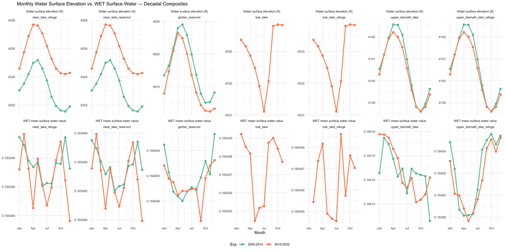

```r
combined_decadal |>
  filter(name %in% plot_areas) |>
  select(name, era_str, month_num, elevation_mean_ft, mean_val) |>
  pivot_longer(c(elevation_mean_ft, mean_val), names_to = "metric", values_to = "value") |>
  mutate(metric = recode(metric,
                         elevation_mean_ft = "Water surface elevation (ft)",
                         mean_val           = "WET mean surface water value")) |>
  ggplot(aes(x = month_num, y = value, color = era_str, group = era_str)) +
  geom_line(linewidth = 0.9) +
  geom_point(size = 2) +
  facet_wrap(vars(metric, name), scales = "free_y", ncol = length(plot_areas)) +
  scale_x_continuous(breaks = c(1, 4, 7, 10), labels = month.abb[c(1, 4, 7, 10)]) +
  scale_color_brewer(palette = "Set2", name = "Era") +
  labs(
    title = "Monthly Water Surface Elevation vs. WET Surface Water — Decadal Composites",
    x = "Month", y = NULL
  ) +
  theme_minimal(base_size = 9) +
  theme(legend.position = "bottom", strip.text = element_text(size = 7))
```

Annual monthly values (2022–present):

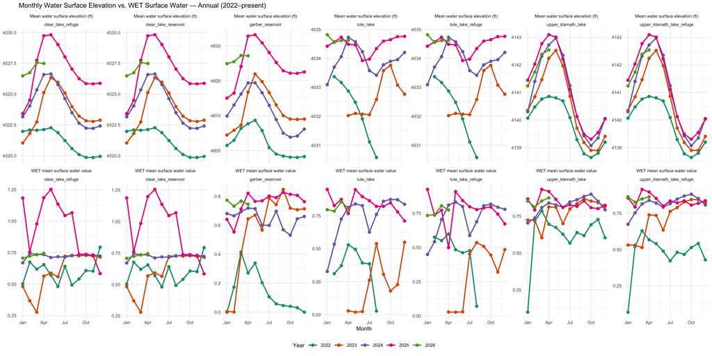

```r
combined_annual |>
  filter(name %in% plot_areas) |>
  select(name, era_start, month_num, elevation_mean_ft, mean_val) |>
  pivot_longer(c(elevation_mean_ft, mean_val), names_to = "metric", values_to = "value") |>
  mutate(metric = recode(metric,
                         elevation_mean_ft = "Mean water surface elevation (ft)",
                         mean_val           = "WET mean surface water value")) |>
  ggplot(aes(x = month_num, y = value, color = factor(era_start), group = era_start)) +
  geom_line(linewidth = 0.9) +
  geom_point(size = 2) +
  facet_wrap(vars(metric, name), scales = "free_y", ncol = length(plot_areas)) +
  scale_x_continuous(breaks = c(1, 4, 7, 10), labels = month.abb[c(1, 4, 7, 10)]) +
  scale_color_brewer(palette = "Dark2", name = "Year") +
  labs(
    title = "Monthly Water Surface Elevation vs. WET Surface Water — Annual (2022–present)",
    x = "Month", y = NULL
  ) +
  theme_minimal(base_size = 9) +
  theme(legend.position = "bottom", strip.text = element_text(size = 7))
```

## 6.1 Elevation range within each decadal month

The decadal composites average 10 years of daily elevation into one monthly value, which can hide how much a reservoir actually swings within that window. Plotting the min–max range alongside the mean shows that spread directly.

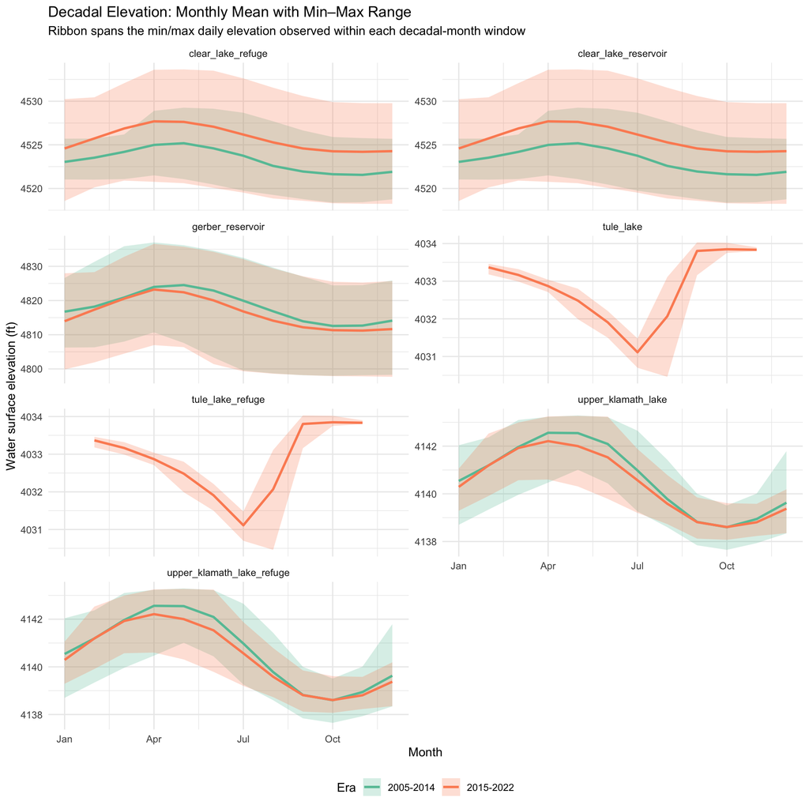

```r
combined_decadal |>
  filter(name %in% plot_areas) |>
  ggplot(aes(x = month_num, group = era_str)) +
  geom_ribbon(aes(ymin = elevation_min_ft, ymax = elevation_max_ft, fill = era_str), alpha = 0.25) +
  geom_line(aes(y = elevation_mean_ft, color = era_str), linewidth = 1) +
  facet_wrap(~name, scales = "free_y", ncol = 2) +
  scale_x_continuous(breaks = c(1, 4, 7, 10), labels = month.abb[c(1, 4, 7, 10)]) +
  scale_color_brewer(palette = "Set2", name = "Era") +
  scale_fill_brewer(palette = "Set2", name = "Era") +
  labs(
    title    = "Decadal Elevation: Monthly Mean with Min–Max Range",
    subtitle = "Ribbon spans the min/max daily elevation observed within each decadal-month window",
    x = "Month", y = "Water surface elevation (ft)"
  ) +
  theme_minimal(base_size = 11) +
  theme(legend.position = "bottom")
```

```r
knitr::knit_exit()
```